# Statistical Analysis for Marriage in HappyDB

Zongbo Cai

[figure not shown]

## Introduction.

HappyDB is a corpus of 100,000 crowd-sourced happy moments. There are many interesting phenomena that can be revealed by the data in this database. Many people say that marriage is the grave of love. Does marriage have impact on people’s feelings, especially on happy things? What do people do before and after marriage? Let’s take a look.

## Overall of whole dataset.

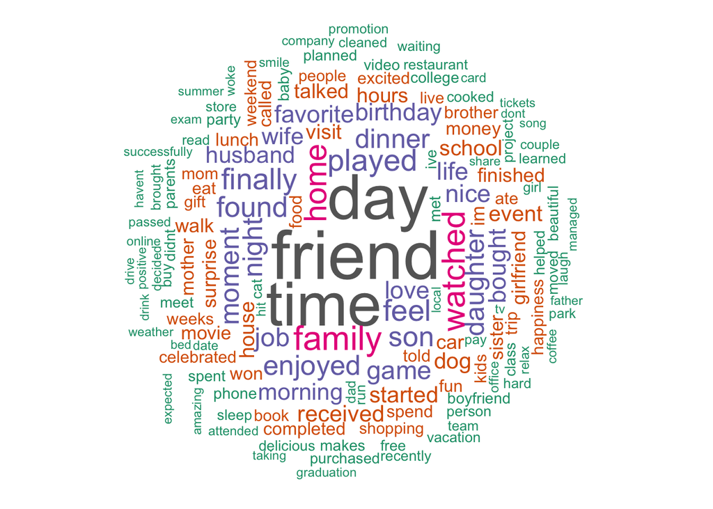

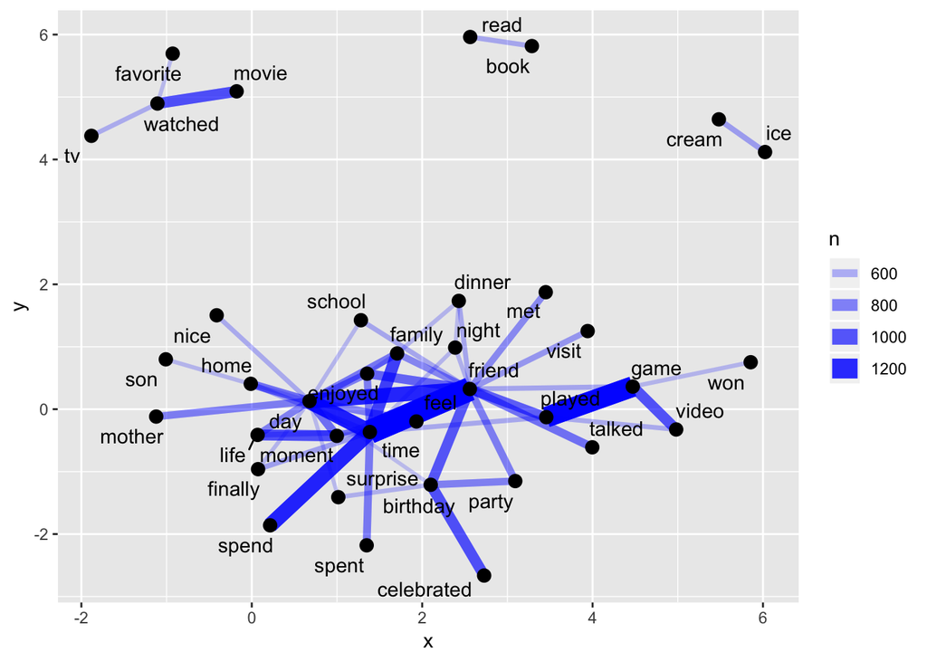

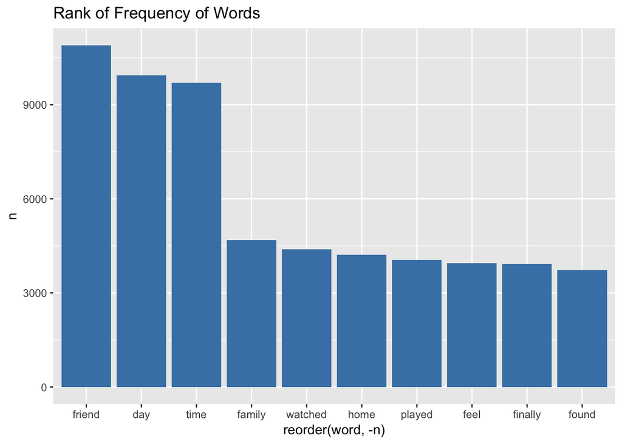

Let’s first take a look at what this database looks like. After I split the entire corpus, I draw a bar plot. It can be seen from the figure that the words friends, day, time, family, watched, and home have the highest frequency. The wordcloud above is another interesting illustration of frequency of the words. As you can see from netgraph, how often these words are connected to other words. For example, time and family have strong connections, so as video and game.

## Category analysis

There are some very common problems, for example, will people change before and after marriage? What is the difference between a man and a woman in their marriage?

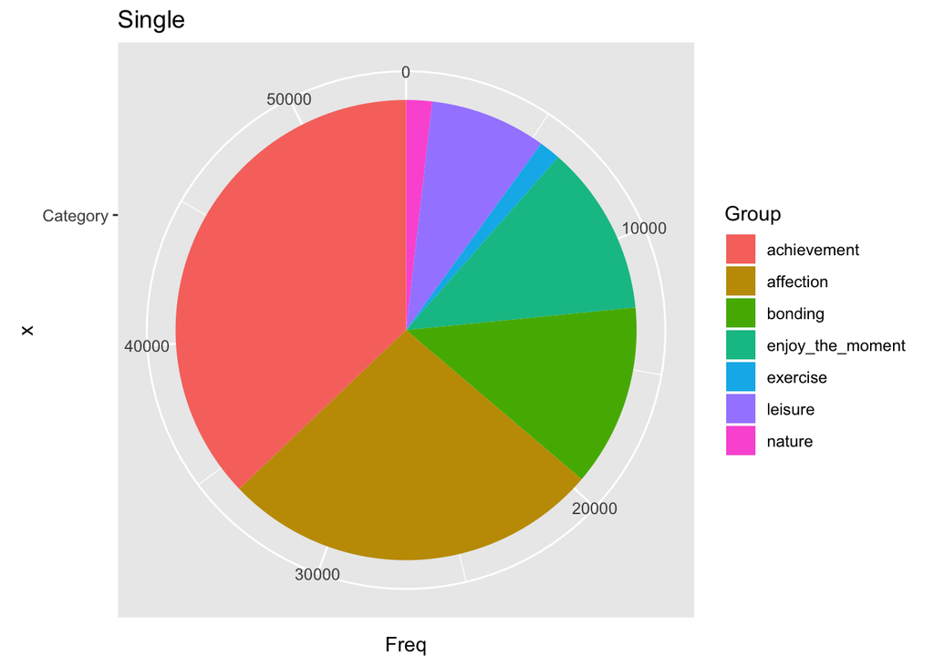

```r
single_pred_category
```

| Var1 | Freq | prop |
| --- | --- | --- |
| achievement | 20047 | 37.1% |
| affection | 14402 | 26.7% |
| bonding | 6908 | 12.8% |
| enjoy_the_moment | 6465 | 12.0% |
| leisure | 4400 | 8.1% |
| nature | 982 | 1.8% |
| exercise | 811 | 1.5% |

```r
married_pred_category
```

| Var1 | Freq | prop |
| --- | --- | --- |
| affection | 17897 | 43.3% |
| achievement | 12159 | 29.4% |
| enjoy_the_moment | 4113 | 10.0% |
| bonding | 3316 | 8.0% |
| leisure | 2731 | 6.6% |
| nature | 737 | 1.8% |
| exercise | 347 | 0.8% |

(The first table is for single and the second is for married people.)

I used the demographic information in the database to extract the happy moment for single and married people. In the pie chart, it is obvious that the proportion of “affection”, that is, love, has increased significantly. In contrast, “achievement” has been significantly reduced. At the same time, people have less happy moments of leisrue, and the happy moment of exercise is relatively less. This results are consistent with our common sense. Compared with singles, people don’t have so much personal disposable time after getting married. They have to spend more time facing their family.

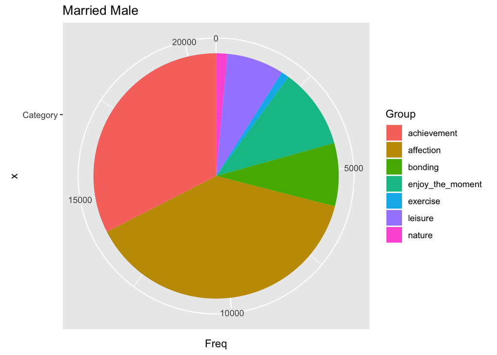

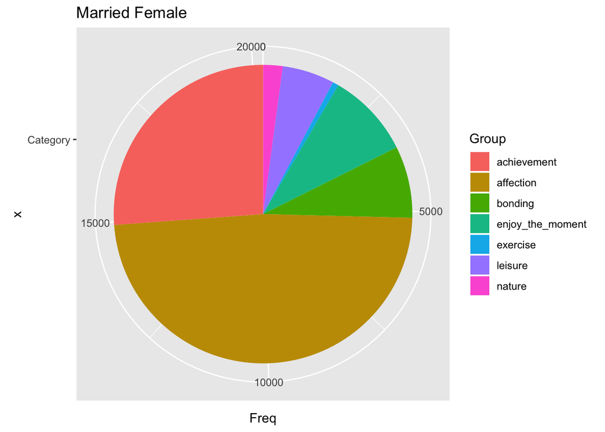

```r
married_male_pred_category
```

| Var1 | Freq | prop |
| --- | --- | --- |
| affection | 7994 | 38.5% |
| achievement | 6752 | 32.5% |
| enjoy_the_moment | 2208 | 10.6% |
| bonding | 1728 | 8.3% |
| leisure | 1566 | 7.5% |
| nature | 305 | 1.5% |
| exercise | 214 | 1.0% |

```r
married_female_pred_category
```

| Var1 | Freq | prop |
| --- | --- | --- |
| affection | 9798 | 48.4% |
| achievement | 5290 | 26.2% |
| enjoy_the_moment | 1863 | 9.2% |
| bonding | 1572 | 7.8% |
| leisure | 1143 | 5.7% |
| nature | 429 | 2.1% |
| exercise | 129 | 0.6% |

(The first table is for married male and the second is for married female.)

In this comparison of married men and women, we can see that men have more “achievement” happy moments than women. Women’s “affection” happy moment is more than men. This is also in line with our ideas. Men are more engaged with careers or other things that make them feel more “achievement” than women. On the other hand, women are more emotional.

## Entertainment comparison

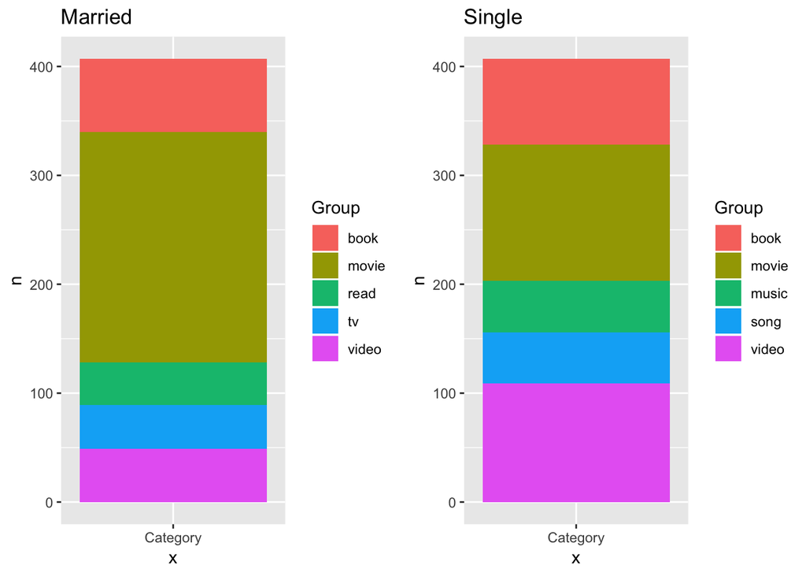

Will the entertainment activities of people change before and after marriage? I took people’s first five entertainment, activities according to the frequency of the two groups of activities, before and after marriage and compared them. It should be noted that the “video” here actually represents video games. We can very clearly find that after marriage, the happy moments of people playing video games are significantly reduced. (My girlfriend doesn’t allow me to play games. Sad.) In contrast, the happy moment of watching movies has increased a lot. This phenomenon is very reasonable. The joy of plaaying computer or console game is belong to a single person. Because other than the participants, people watching are not so easy to get joy. However, the fun of watching movies with the family can be shared with family members.

## Exercises comparison

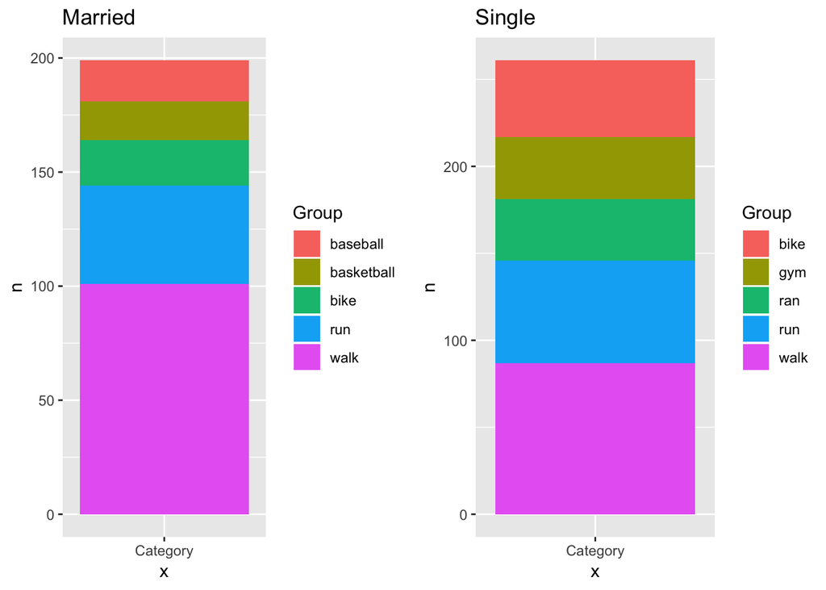

[figure not shown]

## Conclusion

After the marriage, people’s happy moments will indeed change. Compared with singles, people will do more family activities to share joy, such as watching movies, playing basketball, and so on. When you are single, more happiness comes from “achievement.” And when you get married, more happiness comes from joy from the other half or the the family.